# Data Cleaning Script

Rebecca Folmer Schade & Sophia Kleist Karlson

2021-05-11 updated 2021-09-01

## Loading packages

```r
# Quick install/load of all used packages if needed
# install.packages("pacman")
# pacman::p_load(pacman, osmdata, sf, tidyverse, raster)
library(osmdata)
library(sf)
library(tidyverse)
library(raster)
```

# Data gathering and cleaning

In this script, data on LGBT+ friendly amenities in the European Economic Area (EEA) and Switzerland is gathered from Open Street Maps and cleaned for use in the Leaflet visualization.

## Querying data from Open street maps

Data is queried withing the three bounding boxes that contain the keys gay= and lgbtq= with all associated values indicating that the location is lgbt+ friendly (gay=yes/welcome/only and lgbtq=primary/only/yes). Though the wiki for the lgbtq key discourages the use of lgbtq=yes, it still queried as some data was coded as such [(link here, last read 2021-05-25)](https://wiki.openstreetmap.org/wiki/Key:lgbtq).

Because of the scattering of European territories, the data is queried from within three bounding boxes - one containing most of Europe, one containing the Danish territory Greenland, and one containing the French territory French Guiana.

```r
# Sourcing the script "OSMQuery.R"
source("scripts/OSMQuery.R")

#===> Saving data in a way that is compatible with the sf package
# Removing components of the osmdata that are duplicated within the object
EEA_safe_unique <- unique_osmdata(EEA_safe_spaces)
colnames(raw_points)
# Removing unneeded variables (as datasets that have too many fields/columns are hard to save)
raw_points <- EEA_safe_unique$osm_points %>%  dplyr::select(osm_id, name, amenity, opening_hours, website)
raw_polygons <- EEA_safe_unique$osm_polygons %>%  dplyr::select(osm_id, name, amenity, opening_hours, website)
raw_lines <- EEA_safe_unique$osm_lines %>% dplyr::select(osm_id, name, amenity, opening_hours, website)
raw_multipolygons <- EEA_safe_unique$osm_multipolygons %>% dplyr::select(osm_id, name, amenity)
# Sorting out issues with encoding of characters
raw_points$name <- iconv(raw_points$name, from = "UTF-8", to = "UTF-8")
raw_points$opening_hours <- iconv(raw_points$opening_hours, from = "UTF-8", to = "UTF-8")
#
raw_polygons$name <- iconv(raw_polygons$name, from = "UTF-8", to = "UTF-8")
raw_polygons$opening_hours <- iconv(raw_polygons$opening_hours, from = "UTF-8", to = "UTF-8")
#
raw_lines$name <- iconv(raw_lines$name, from = "UTF-8", to = "UTF-8")
raw_lines$opening_hours <- iconv(raw_lines$opening_hours, from = "UTF-8", to = "UTF-8")
#
raw_multipolygons$name <- iconv(raw_multipolygons$name, from = "UTF-8", to = "UTF-8")
# Saving data
st_write(raw_points, "data/raw/EEA_raw_points5.shp", layer_options = "ENCODING=UTF-8", delete_layer = TRUE)
st_write(raw_polygons, "data/raw/EEA_raw_polygons5.shp", layer_options = "ENCODING=UTF-8", delete_layer = TRUE)
st_write(raw_lines, "data/raw/EEA_raw_lines5.shp", layer_options = "ENCODING=UTF-8", delete_layer = TRUE)
st_write(raw_multipolygons, "data/raw/EEA_raw_multipolygons5.shp", layer_options = "ENCODING=UTF-8", delete_layer = TRUE)
```

## Loading data

```r
# Loading data for cleaning
raw_points <- st_read("data/raw/EEA_raw_points.shp", options = "ENCODING=UTF-8")
raw_polygons <- st_read("data/raw/EEA_raw_polygons.shp", options = "ENCODING=UTF-8")
raw_lines <- st_read("data/raw/EEA_raw_lines.shp", options = "ENCODING=UTF-8")
raw_multipolygons <- st_read("data/raw/EEA_raw_multipolygons.shp", options = "ENCODING=UTF-8")
```

## Cleaning the data

### Creating a map of countries in the EEA (+ Switzerland)

While the main visualizations are made in leaflet, this is useful for quick illustrations and subsetting data. The map is made with data from [ec.eurostat.eu](https://ec.europa.eu/eurostat/web/gisco/geodata/reference-data/administrative-units-statistical-units/countries) (© EuroGeographics for the administrative boundaries).

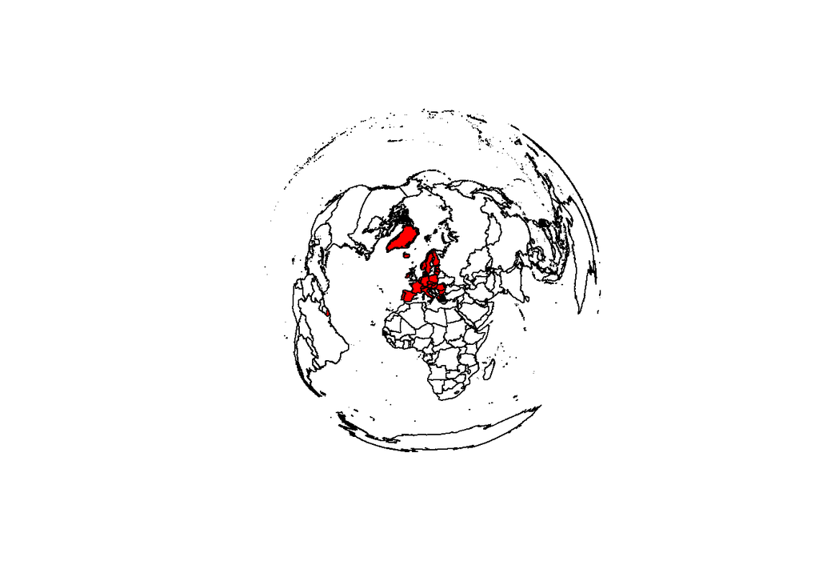

```r
# loading data from eurostat
world_geo <- st_read("data/CNTR_RG_01M_2020_3035.shp/CNTR_RG_01M_2020_3035.shp")
head(world_geo)

# Let's try plotting the data
plot(st_geometry(world_geo))

# Creating a list of countries that are members of the EEA
EEA_members <- c("Austria", "Belgium", "Bulgaria", "Croatia", "Cyprus", "Czechia", "Denmark", "Estonia", "Finland", "France", "Germany", "Greece", "Hungary", "Iceland", "Ireland", "Italy", "Latvia", "Liechtenstein", "Lithuania", "Luxembourg", "Malta", "Netherlands", "Norway", "Poland", "Portugal", "Romania", "Slovakia", "Slovenia", "Spain", "Sweden", "Switzerland")
# > With the excption of Switzerland, the list was taken from https://ec.europa.eu/eurostat/statistics-explained/index.php?title=Glossary:European_Economic_Area_(EEA) (2021-05-25)

# Checking to see if Anything was overlooked in this list
sort(unique(world_geo$NAME_ENGL))
# > Though a part of the Danish Commonwealth, Greenland and the Faroes have their own entries in the dataset

# Adding the Faroes to the list
EEA_members <- c(EEA_members, "Faroes", "Greenland")
EEA_members

# Checking that all countries in the EEA_members list are present in the dataset
EEA_members %in% world_geo$NAME_ENGL

# Creating a map only with the countries in the EEA for subsetting data later on
EEA_geo <- world_geo %>% dplyr::filter(NAME_ENGL %in% EEA_members)

# Showing EEA territories in a plot
plot(st_geometry(world_geo));plot(st_geometry(EEA_geo), col = "red", fil = "red", add = TRUE)
```

### Transforming, merging, and subsetting data

```r
# Isolate the points and change projection
EEA_rpoint <- raw_points %>%
  st_transform(crs = 3035)

# Change the projecttion, isolate the polygons Compute centroids of the polygons, and store data as points
EEA_rpoly  <- raw_polygons %>%
  st_transform(crs = 3035) %>%
  st_centroid()

# > the lines and multipolygons are saved in separate objects because thay are unexpected in the query, and will be examined separately
EEA_rline <- raw_lines %>%
  st_transform(crs = 3035)
EEA_rmultipoly <- raw_multipolygons %>%
  st_transform(crs = 3035)

# Merging
EEA_safe_osm <- rbind(EEA_rpoly,EEA_rpoint)

# Remove points outside the area of interest
EEA_safe_osm_filtered <- st_intersection(EEA_safe_osm, (EEA_geo %>% st_geometry() %>% st_union()))
```

### Having a look at the lines and multipolygons

```r
# Looking at multipolygons
head(EEA_rmultipoly)
```

```
## Simple feature collection with 3 features and 3 fields
## Geometry type: POLYGON
## Dimension:     XY
## Bounding box:  xmin: 3668178 ymin: 1733166 xmax: 5994106 ymax: 3955223
## Projected CRS: ETRS89-extended / LAEA Europe
##     osm_id                   name amenity                       geometry
## 1 10169108                  Porta     bar POLYGON ((5677677 1733173, ...
## 2     <NA>                   <NA>    <NA> POLYGON ((5993952 3955124, ...
## 3  2175043 Platja de la Mar Bella    <NA> POLYGON ((3668228 2066424, ...
```

```r
# Looking at linestrings
head(EEA_rline)
```

```
## Simple feature collection with 6 features and 5 fields
## Geometry type: LINESTRING
## Dimension:     XY
## Bounding box:  xmin: 5677660 ymin: 1733166 xmax: 5994106 ymax: 3955223
## Projected CRS: ETRS89-extended / LAEA Europe
##      osm_id name amenity opnng_h website                       geometry
## 1 690037079 <NA>    <NA>    <NA>    <NA> LINESTRING (5677677 1733173...
## 2 736244336 <NA>    <NA>    <NA>    <NA> LINESTRING (5677674 1733173...
## 3  88265812 <NA>    <NA>    <NA>    <NA> LINESTRING (5993952 3955124...
## 4 429187176 <NA>    <NA>    <NA>    <NA> LINESTRING (5993879 3955082...
## 5 515479782 <NA>    <NA>    <NA>    <NA> LINESTRING (5993855 3955149...
## 6 914400432 <NA>    <NA>    <NA>    <NA> LINESTRING (5994106 3955159...
```

When one looks at the dataframes themselves, one can see that the lines lack values in most of the columns we found relevant, and that the multypolugons lack the columns for most of these categories to begin with. Given this (and that we are not sure what these geometries are supposed to represent to begin with), we have elected to exclude them from further analysis.

### Cleaning variables

As these variables will be used in the visualization, they should be made a little prettier to look at.

```r
#=====> Cleaning EEA_point_select <=====#
#===> Cleaning $name
unique(EEA_safe_osm_filtered$name)
# > I identified two issues: Some entries with small first letters, and the use of quetation marks.
# Fixing the unneded quotation marks
EEA_safe_osm_filtered$name <- str_replace_all(EEA_safe_osm_filtered$name, pattern = "\"", replacement = "")
# Fixing the small first letters
EEA_safe_osm_filtered$name <- str_to_title(EEA_safe_osm_filtered$name)

#===> Cleaning $amenity
unique(EEA_safe_osm_filtered$amenity)
# > two issues: the use of underscores instead of space and lack of capitalization
# Fixing the use of underscores
EEA_safe_osm_filtered$amenity <- str_replace_all(EEA_safe_osm_filtered$amenity, pattern = "_", replacement = " ")
# Fixing the capitalization
EEA_safe_osm_filtered$amenity <- str_to_sentence(EEA_safe_osm_filtered$amenity)
```

## Saving data

```r
#===> Saving data in the data folder
st_write(EEA_safe_osm_filtered, "data/EEA_points.shp")
```